# Анализ вакансий аналитиков на hh.ru

### Какие работодатели чаще ищут аналитиков?

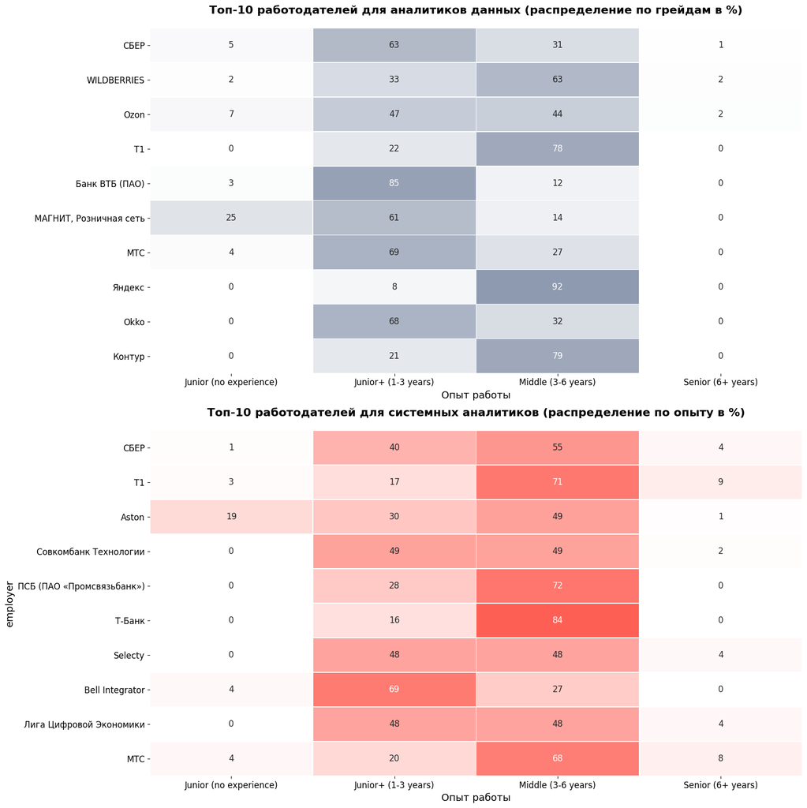

```python
# Создадим градиентные цветовые карты вручную.

from matplotlib.colors import LinearSegmentedColormap

# Функция для создания градиентной палитры от белого к заданному цвету
def create_gradient_palette(start_color, end_color="white", num_colors=256):
    """
    Создает градиентную палитру от белого к начальной цветовой точке.
    """
    return LinearSegmentedColormap.from_list("custom_gradient", [end_color, start_color], N=num_colors)

# Создаем кастомные палитры с нужным направлением градиента
sa_cmap = create_gradient_palette(sa_color)  # Градиент от белого к красному (для системных аналитиков)
da_cmap = create_gradient_palette(da_color)  # Градиент от белого к зеленому (для аналитиков данных)

def prepare_heatmap_data(data, profession, top_n=10):
    # Определяем топ-N работодателей для конкретной профессии
    top_employers = (
        data[data['profession'] == profession]['employer']
        .value_counts()
        .nlargest(top_n)
        .index
    )

    # Фильтруем данные для тепловой карты
    heatmap_data = (
        data[(data['profession'] == profession) & (data['employer'].isin(top_employers))]
        .groupby(['employer', 'experience'])['id']
        .count()
        .reset_index()
        .pivot(index='employer', columns='experience', values='id')
        .fillna(0)
    )

    # Считаем общую сумму вакансий для каждой компании
    heatmap_data['total'] = heatmap_data.sum(axis=1)

    # Сортируем компании по убыванию общего количества вакансий
    heatmap_data = heatmap_data.sort_values(by='total', ascending=False)

    # Убираем столбец total (он не нужен для отображения)
    heatmap_data = heatmap_data.drop(columns='total')

    # Рассчитываем проценты от общего числа вакансий для каждой компании
    heatmap_data = heatmap_data.div(heatmap_data.sum(axis=1), axis=0) * 100

    return heatmap_data

# Подготовка данных для тепловой карты
sa_heatmap = prepare_heatmap_data(df_filtered, 'Системный аналитик')
da_heatmap = prepare_heatmap_data(df_filtered, 'Аналитик данных')

# Построение тепловых карт
fig, axes = plt.subplots(2, 1, figsize=(16, 16), sharey=False)

# Тепловая карта для системных аналитиков
sns.heatmap(
    da_heatmap,
    annot=True,
    fmt=".0f",
    cmap=da_cmap,  # Используем градиент от белого к красному
    ax=axes[0],
    cbar=False,
    linewidths=0.5,
    annot_kws={"fontsize": 12},  # Увеличиваем шрифт значений внутри ячеек
)

axes[1].set_title(
    "Топ-10 работодателей для системных аналитиков (распределение по опыту в %)",
    fontsize=16,
    pad=20,
    fontweight="bold",
)
axes[0].set_xlabel("Опыт работы", fontsize=14)
axes[1].set_ylabel("", fontsize=14)
axes[1].tick_params(axis="both", which="major", labelsize=12)

# Тепловая карта для аналитиков данных
sns.heatmap(
    sa_heatmap,
    annot=True,
    fmt=".0f",
    cmap=sa_cmap,  # Используем градиент от белого к зеленому
    ax=axes[1],
    cbar=False,
    linewidths=0.5,
    annot_kws={"fontsize": 12},  # Увеличиваем шрифт значений внутри ячеек
)

axes[0].set_title(
    "Топ-10 работодателей для аналитиков данных (распределение по грейдам в %)",
    fontsize=16,
    pad=20,
    fontweight="bold",
)
axes[1].set_xlabel("Опыт работы", fontsize=14)
axes[0].set_ylabel("", fontsize=14)
axes[0].tick_params(axis="both", which="major", labelsize=12)

plt.tight_layout()
plt.show()
```

- Больше всех вакансий для обеих профессий может предложить «Сбер», предпочтение в них отдаётся специалистам Junior+ (40% вакансий кампании) и Middle (55% вакансий кампании) уровня.
- Среди крупных компаний, набирающих наибольшая аналитиков данных по доле junior специалистов, выделяется «Магнит» (25% вакансий кампании), а для системных аналитиков — Aston (19% вакансий кампании).
- Наиболее типичные компании для аналитиков данных: крупные IT и «бигтех» компании, а также e-commerce, банки и ритейл.
- Для системных аналитиков ситуация похожая, однако с большим уклоном непосредственно к разработке продукта в IT-сфере.
- Доля вакансий Junior и Senior специалистов очень мала, крупные IT-компании зачастую имеют свои образовательные платформы, где выращивают будущих стажеров, а также проводят Week Offers для отбора перспективных специалистов.